# Supplementary Material for Sluis et al. 2022

R Session info:

```r
print(session, locale = FALSE)
```

[output not shown]

Age group definitions:

| Age category | Age range |
| --- | --- |
| 1 | 0 – 19 |
| 2 | 20 – 29 |
| 3 | 30 – 39 |
| 4 | 40 – 49 |
| 5 | 50 – 59 |
| 6 | 60 – 69 |
| 7 | 70 – 79 |
| 8 | 80 – 89 |

# 1 Summary statistics

## 1.1 Age-at-death within the sample

```r
# Age
  # descriptive statistics for whole sample
age_summ_tot <- region_means_all %>%
  filter(region == "all",
         method == "snodgrass") %>%
  count(id, known_age) %>%
  summarise(n = n(),
            mean = mean(known_age, na.rm = T),
            sd = sd(known_age, na.rm = T),
            range = paste(range(known_age, na.rm = T), collapse = "--")) %>%
  mutate(sex = "Both", .before = mean)
  # descriptive statistics by age category and sex
age_group_summ <- region_means_all %>%
  group_by(age_group, sex) %>%
  count(id, known_age) %>%
  summarise(n = n(),
            mean = mean(known_age, na.rm = T), # mean age within each age cat
            sd = sd(known_age, na.rm = T))

age_sex_summ <- region_means_all %>%
  group_by(sex) %>%
  count(id, known_age) %>%
  summarise(n = n(),
            mean = mean(known_age, na.rm = T),
            sd = sd(known_age, na.rm = T),
            range = paste(range(known_age, na.rm = T), collapse = "--")) %>%
  add_row(age_summ_tot)

females <- age_sex_summ %>%
  filter(sex == "F")
males <- age_sex_summ %>%
  filter(sex == "M")
```

Table S1.1 Summary statistics for age-at-death.

| sex | n | mean | sd | range |
| --- | --- | --- | --- | --- |
| F | 48 | 46.89583 | 17.51017 | 20–80 |
| M | 40 | 52.27500 | 21.02012 | 19–84 |
| Both | 88 | 49.34091 | 19.26040 | 19–84 |

Table S1.2 Summary statistics for grouped ages-at-death.

| age_group | sex | n | mean | sd |
| --- | --- | --- | --- | --- |
| 1 | M | 1 | 19.00000 | NA |
| 2 | F | 12 | 25.50000 | 3.554766 |
| 2 | M | 7 | 23.14286 | 2.410295 |
| 3 | F | 6 | 32.33333 | 3.444803 |
| 3 | M | 6 | 34.33333 | 3.141125 |
| 4 | F | 8 | 45.75000 | 2.434866 |
| 4 | M | 3 | 44.33333 | 2.081666 |
| 5 | F | 10 | 54.90000 | 2.685351 |
| 5 | M | 6 | 56.66667 | 1.751190 |
| 6 | F | 7 | 65.00000 | 2.828427 |
| 6 | M | 6 | 63.83333 | 3.868678 |
| 7 | F | 4 | 75.25000 | 3.403430 |
| 7 | M | 7 | 74.28571 | 2.138090 |
| 8 | F | 1 | 80.00000 | NA |
| 8 | M | 4 | 82.00000 | 1.825742 |

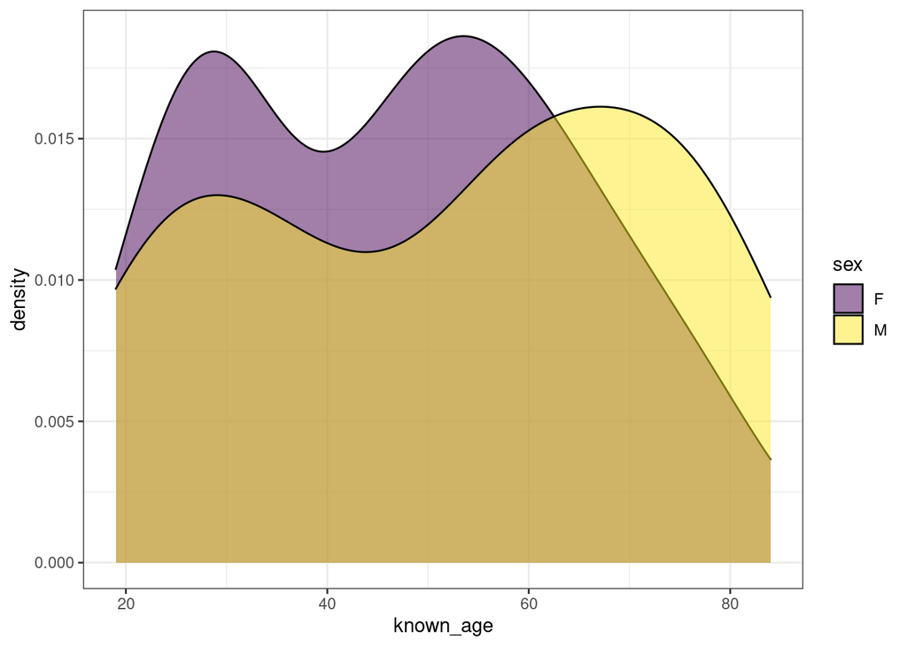

Figure S1.1 Age distribution for each sex. F = Female, M = Male.

```r
raw_data %>%
  filter(vertebral_position == "Superior") %>%
  ggplot(aes(x = known_age, fill = sex)) +
    geom_density(alpha = 0.5) +
    scale_fill_viridis_d() +
  theme_bw()
```

## 1.2 Osteophyte scores

A comparison of osteophyte scores between methods.

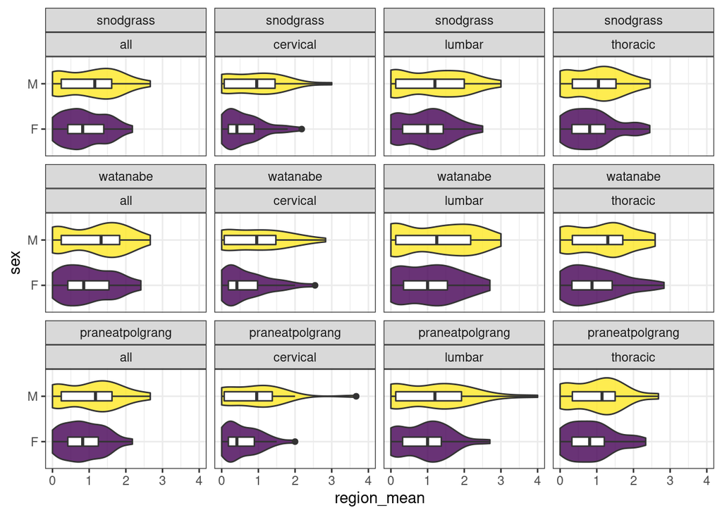

Figure S1.2 Comparing osteophyte scores between sex, separated by region and method.

```r
region_means_all %>%
  ggplot(aes(x = sex, y = region_mean, fill = sex)) +
    geom_violin(alpha = 0.8) +
    geom_boxplot(width = 0.2, fill = "white") +
    facet_wrap(~ method + region) +
    coord_flip() +
    scale_fill_viridis_d() +
    theme_bw() +
    theme(legend.position = "none")
```

# 2 Correlation tests

```r
cor_test <- region_means_all %>%
  filter(region == "all", sex == "F", method == "snodgrass") %>%
  dplyr::select(region_mean, known_age)
cor_f <- cor.test(cor_test$region_mean, cor_test$known_age) %>%
  tidy()

cor_test <- region_means_all %>%
  filter(region == "all", sex == "M", method == "snodgrass") %>%
  dplyr::select(region_mean, known_age)
cor_m <- cor.test(cor_test$region_mean, cor_test$known_age) %>%
  tidy()

cor_f %>%
  bind_rows(cor_m) %>%
  mutate(sex = c("F", "M"), .before = 1) %>%
  knitr::kable(caption = "Pearson correlation coefficients for Snodgrass osteophyte score for combined regions, and age-at-death. Separated by Sex.")
```

Table S2.1 Pearson correlation coefficients for Snodgrass osteophyte score for combined regions, and age-at-death. Separated by Sex.

| sex | estimate | statistic | p.value | parameter | conf.low | conf.high | method | alternative |
| --- | --- | --- | --- | --- | --- | --- | --- | --- |
| F | 0.7176649 | 6.989546 | 0 | 46 | 0.5445767 | 0.8321192 | Pearson’s product-moment correlation | two.sided |
| M | 0.8664245 | 10.696801 | 0 | 38 | 0.7600529 | 0.9275805 | Pearson’s product-moment correlation | two.sided |

Males (0.8664245) have a higher correlation between osteophyte score and age than females (0.7176649). Both have strong correlations.

# 3 Weighted least squares regression

Models were built using weights estimated with a standard deviation function regressing the absolute values of the residuals on the predictor, i.e. known age. The weights were then calculated as the inverse of the squared standard deviation function.

$$w_i = \frac{1}{\sigma^2_i}$$

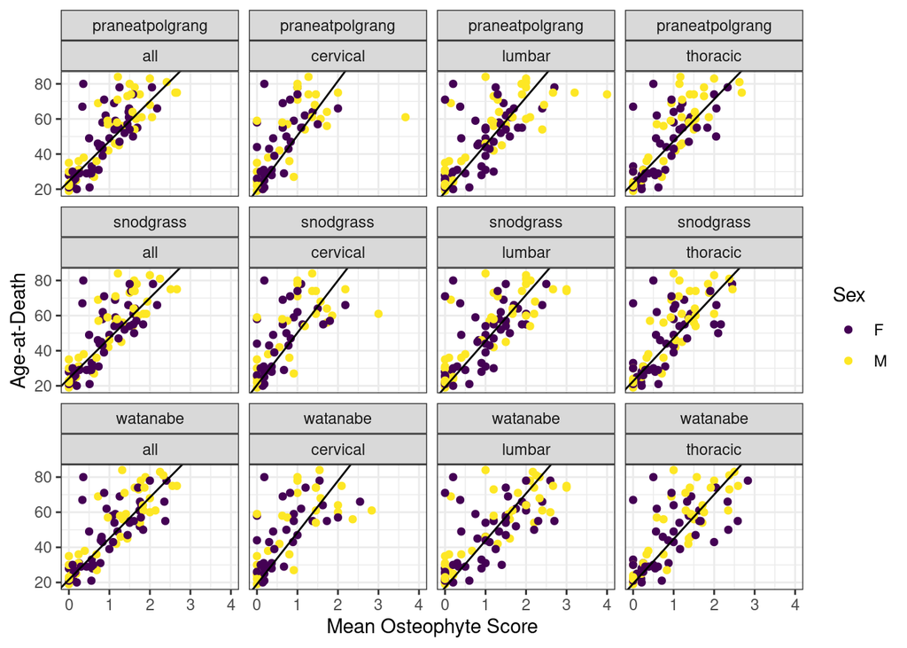

Figure S3.1 Regression plots for all regions and methods. F = Female, M = Male.

```r
# Code to generate wls regression lines for facet plot
reg_plots <- region_means_all %>%
  #group_by(feat, known_age, sex, region, method) %>%
  #summarise(region_mean = mean(score, na.rm = T)) %>%
  ggplot(aes(x = region_mean, known_age)) +
    geom_point(aes(col = sex)) +
    scale_color_viridis_d(name = "Sex") +
    facet_wrap(~ method + region) +
    theme_bw() +
    labs(x = "Mean Osteophyte Score", y = "Age-at-Death")

# Insert coefficients into table
snodgrass_coefs <- lapply(snodgrass_wls, coef) %>%
  unlist() %>%
  matrix(byrow = T, nrow = 4, ncol = 2)
watanabe_coefs <- lapply(watanabe_wls, coef) %>%
  unlist() %>%
  matrix(byrow = T, nrow = 4, ncol = 2)
praneatpolgrang_coefs <- lapply(praneatpolgrang_wls, coef) %>%
  unlist() %>%
  matrix(byrow = T, nrow = 4, ncol = 2)
all_coefs <- rbind(praneatpolgrang_coefs, snodgrass_coefs, watanabe_coefs)
# Create data frame to pass to geom_abline
reg_coefs <- data.frame("method" = c(rep("praneatpolgrang", 4),
                                     rep("snodgrass", 4),
                                     rep("watanabe", 4)),
                        "region" = rep(c("all", "cervical", "lumbar", "thoracic")),
                        "slope" = all_coefs[,1],
                        "intercept" = all_coefs[,2])
reg_plots +
    geom_abline(aes(slope = slope, intercept = intercept), reg_coefs)
```

```r
ggsave(here("fig_output", "wls_plots.jpg"),
      dpi = 600, height = 6, width = 7.5, units = "in")
```

## 3.1 Snodgrass

```r
lapply(snodgrass_wls, extract_eq, use_coefs = T)
```

$all
$$\operatorname{\widehat{known\_age}} = 22.93 + 24.22(\operatorname{region\_mean})$$

$cervical
$$\operatorname{\widehat{known\_age}} = 29.81 + 20.4(\operatorname{region\_mean})$$

$lumbar
$$\operatorname{\widehat{known\_age}} = 26.3 + 19.17(\operatorname{region\_mean})$$

$thoracic
$$\operatorname{\widehat{known\_age}} = 24.53 + 22.62(\operatorname{region\_mean})$$

## 3.2 Watanabe et al.

```r
lapply(watanabe_wls, extract_eq, use_coefs = T)
```

$all
$$\operatorname{\widehat{known\_age}} = 23.41 + 21.6(\operatorname{region\_mean})$$

$cervical
$$\operatorname{\widehat{known\_age}} = 29.43 + 19.04(\operatorname{region\_mean})$$

$lumbar
$$\operatorname{\widehat{known\_age}} = 26.77 + 17.1(\operatorname{region\_mean})$$

$thoracic
$$\operatorname{\widehat{known\_age}} = 25.39 + 19.29(\operatorname{region\_mean})$$

## 3.3 Praneatpolgrang et al.

```r
lapply(praneatpolgrang_wls, extract_eq, use_coefs = T)
```

$all
$$\operatorname{\widehat{known\_age}} = 22.8 + 24.5(\operatorname{region\_mean})$$

$cervical
$$\operatorname{\widehat{known\_age}} = 31.05 + 19.54(\operatorname{region\_mean})$$

$lumbar
$$\operatorname{\widehat{known\_age}} = 27.02 + 18.27(\operatorname{region\_mean})$$

$thoracic
$$\operatorname{\widehat{known\_age}} = 23.87 + 23.47(\operatorname{region\_mean})$$

## 3.4 Model evaluation

Models from each of the three methods (Snodgrass, Watanabe et al., and Praneatpolgrang et al.) and four regions (combined, cervical, thoracic, and lumbar) were evaluated using R$^2$, standard error of the estimate (SEE), AIC, and accuracy. Accuracy is calculated as the total number of prediction intervals that contain the known age, and total number of estimates that are within 5, 10, and 15 years of the known age.

```r
all_eval_tbl %>%
  relocate(method, .before = 1) %>%
  knitr::kable(caption = "Evaluation of combined regions models.")
```

Table S3.1 Evaluation of combined regions models.

| method | R2 | SEE | RMSE | AIC | accuracy | accuracy_5 | accuracy_10 | accuracy_15 |
| --- | --- | --- | --- | --- | --- | --- | --- | --- |
| snodgrass | 0.7408885 | 11.98932 | 11.85230 | 655.3249 | 73.86364 | 43.18182 | 70.45455 | 86.36364 |
| watanabe | 0.7383007 | 11.88823 | 11.75236 | 656.2994 | 76.13636 | 45.45455 | 71.59091 | 86.36364 |
| praneatpolgrang | 0.7432913 | 12.03182 | 11.89431 | 654.4726 | 72.72727 | 45.45455 | 69.31818 | 87.50000 |

```r
knitr::kable(cerv_eval_tbl, caption = "Evaluation of cervical region models.")
```

Table S3.2 Evaluation of cervical region models.

| R2 | SEE | RMSE | AIC | accuracy | accuracy_5 | accuracy_10 | accuracy_15 | method |
| --- | --- | --- | --- | --- | --- | --- | --- | --- |
| 0.4946757 | 15.24596 | 14.99805 | 503.7397 | 67.74194 | 27.41935 | 54.83871 | 75.80645 | snodgrass |
| 0.5087869 | 15.26382 | 15.01561 | 501.8177 | 66.12903 | 27.41935 | 53.22581 | 72.58065 | watanabe |
| 0.4540794 | 15.59793 | 15.34429 | 508.7065 | 69.35484 | 32.25806 | 54.83871 | 75.80645 | praneatpolgrang |

```r
knitr::kable(thor_eval_tbl, caption = "Evaluation of thoracic region models.")
```

Table S3.3 Evaluation of thoracic region models.

| R2 | SEE | RMSE | AIC | accuracy | accuracy_5 | accuracy_10 | accuracy_15 | method |
| --- | --- | --- | --- | --- | --- | --- | --- | --- |
| 0.6373824 | 13.54765 | 13.37507 | 615.8977 | 72.15190 | 37.97468 | 67.08861 | 79.74684 | snodgrass |
| 0.6161718 | 13.76330 | 13.58797 | 620.5676 | 72.15190 | 39.24051 | 69.62025 | 78.48101 | watanabe |
| 0.6636872 | 13.12377 | 12.95659 | 609.7794 | 70.88608 | 39.24051 | 67.08861 | 82.27848 | praneatpolgrang |

```r
knitr::kable(lumb_eval_tbl, caption = "Evaluation of lumbar region models.")
```

Table S3.4 Evaluation of lumbar region models.

| R2 | SEE | RMSE | AIC | accuracy | accuracy_5 | accuracy_10 | accuracy_15 | method |
| --- | --- | --- | --- | --- | --- | --- | --- | --- |
| 0.6305082 | 13.79961 | 13.63820 | 673.3420 | 79.06977 | 38.37209 | 69.76744 | 80.23256 | snodgrass |
| 0.6207949 | 13.80715 | 13.64565 | 675.5420 | 77.90698 | 39.53488 | 67.44186 | 80.23256 | watanabe |
| 0.6057519 | 14.30967 | 14.14230 | 678.9124 | 73.25581 | 39.53488 | 67.44186 | 77.90698 | praneatpolgrang |

### 3.4.1 Diagnostic plots for the combined regions

**Snodgrass**

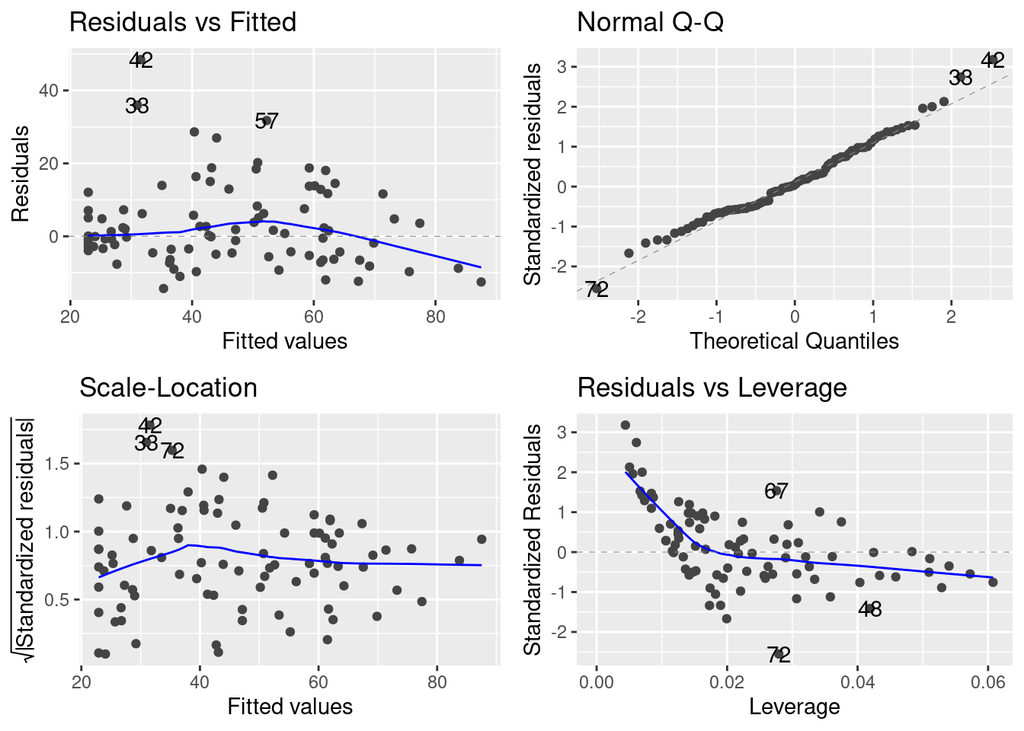

```r
autoplot(snodgrass_wls$all)
```

**Watanabe**

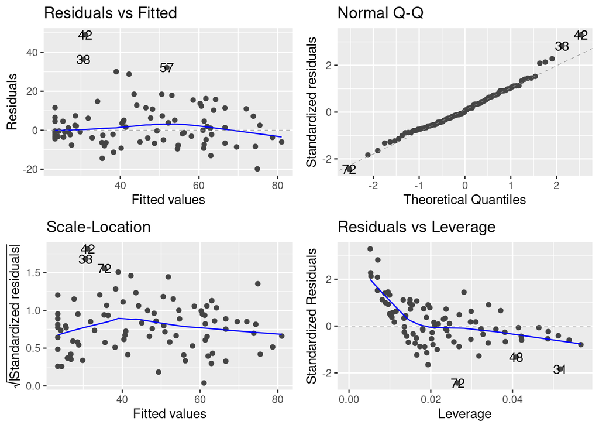

```r
autoplot(watanabe_wls$all)
```

**Praneatpolgrang**

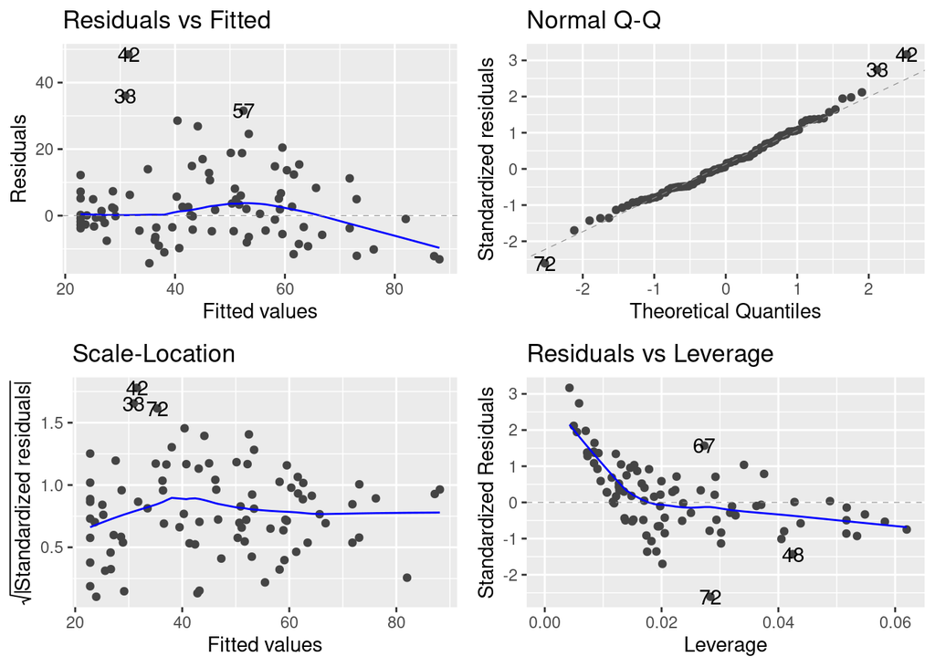

```r
autoplot(praneatpolgrang_wls$all)
```

# 4 Biases

Does the number of elements present influence accuracy?

Graphs show the number of elements and the absolute value of the residuals for the Snodgrass method, to see if there is any relationship between the number of elements scored and the accuracy of the age estimate.

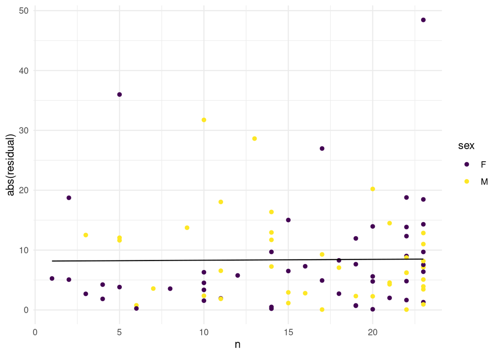

Figure S4.1 Number of elements (n) plotted against the absolute value of the residuals for Snodgrass method, combined regions.

```r
n_elements <- element_data_long %>%
  group_by(id,method,region) %>%
  summarise(n = sum(!is.na(score))) %>%
  ungroup()

n_elements_all <- n_elements %>%
  group_by(id, method) %>%
  summarise(n = sum(n)) %>%
  mutate(region = "all") %>%
  ungroup()

n_all_snodgrass <- n_elements_all %>%
  filter(method == "snodgrass") %>%
  mutate(residual = snodgrass_all_res$residual,
         age = snodgrass_all_res$known_age,
         sex = snodgrass_all_res$sex)

n_all_snodgrass %>%
  ggplot(aes(x = n, y = abs(residual))) +
    geom_point(aes(col = sex)) +
    geom_smooth(method = "lm", se = F, col = "black", size = 0.5) +
    scale_color_viridis_d() +
    theme_minimal()
```

The graph shows that there is no apparent relationship between the number of elements scored and the accuracy of the age, meaning there is no theoretical minimum number of elements that needs to be scored; however, I would recommend that at least 3 elements are scored (preferably more) to obtain reliable results.

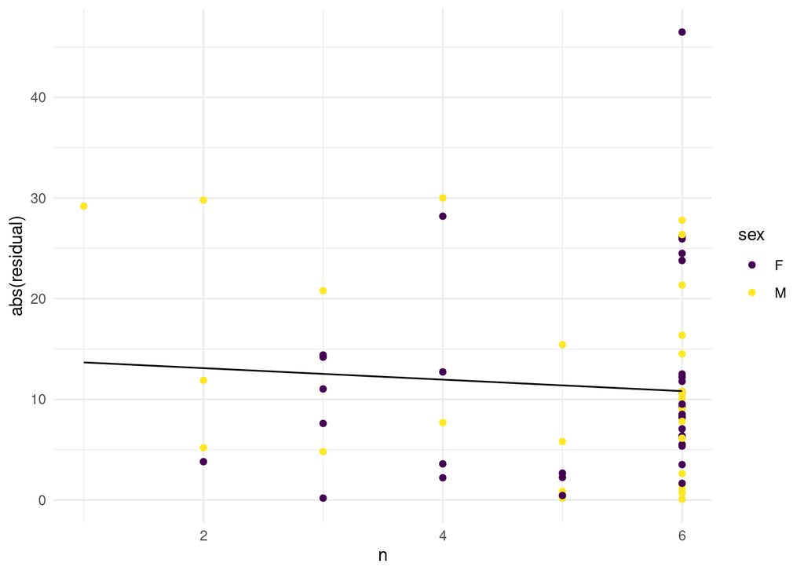

Figure S4.2 Number of elements (n) plotted against the absolute value of the residuals for Snodgrass method, cervical region.

```r
n_elements <- element_data_long %>%
  group_by(id,method,region) %>%
  summarise(n = sum(!is.na(score))) %>%
  ungroup()

n_elements_cerv <- n_elements %>%
  filter(region == "cervical") %>%
  group_by(id, method) %>%
  summarise(n = sum(n)) %>%
  #mutate(region = "cervical") %>%
  ungroup()

n_cerv_snodgrass <- n_elements_cerv %>%
  filter(method == "snodgrass", n != 0) %>%
  mutate(residual = snodgrass_cerv_res$residual,
         age = snodgrass_cerv_res$known_age,
         sex = snodgrass_cerv_res$sex)

n_cerv_snodgrass %>%
  ggplot(aes(x = n, y = abs(residual))) +
    geom_point(aes(col = sex)) +
    geom_smooth(method = "lm", se = F, col = "black", size = 0.5) +
    scale_color_viridis_d() +
    theme_minimal()
```

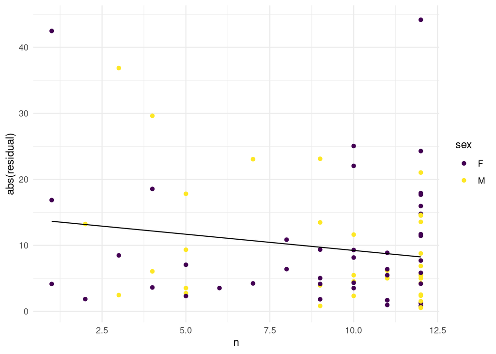

Figure S4.3 Number of elements (n) plotted against the absolute value of the residuals for Snodgrass method, thoracic region.

```r
n_elements <- element_data_long %>%
  group_by(id,method,region) %>%
  summarise(n = sum(!is.na(score))) %>%
  ungroup()

n_elements_thor <- n_elements %>%
  filter(region == "thoracic") %>%
  group_by(id, method) %>%
  summarise(n = sum(n)) %>%
  #mutate(region = "thoracic") %>%
  ungroup()

n_thor_snodgrass <- n_elements_thor %>%
  filter(method == "snodgrass", n != 0) %>%
  mutate(residual = snodgrass_thor_res$residual,
         age = snodgrass_thor_res$known_age,
         sex = snodgrass_thor_res$sex)

n_thor_snodgrass %>%
  ggplot(aes(x = n, y = abs(residual))) +
    geom_point(aes(col = sex)) +
    geom_smooth(method = "lm", se = F, col = "black", size = 0.5) +
    scale_color_viridis_d() +
    theme_minimal()
```

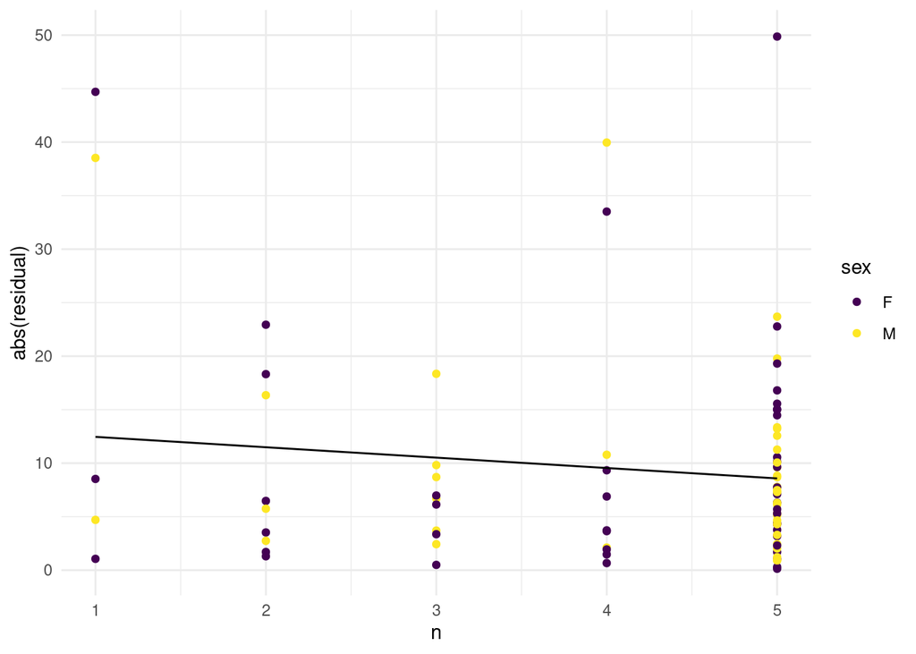

Figure S4.4 Number of elements (n) plotted against the absolute value of the residuals for Snodgrass method, lumbar region.

```r
n_elements <- element_data_long %>%
  group_by(id,method,region) %>%
  summarise(n = sum(!is.na(score))) %>%
  ungroup()

n_elements_lumb <- n_elements %>%
  filter(region == "lumbar") %>%
  group_by(id, method) %>%
  summarise(n = sum(n)) %>%
  #mutate(region = "lumbar") %>%
  ungroup()

n_lumb_snodgrass <- n_elements_lumb %>%
  filter(method == "snodgrass", n != 0) %>%
  mutate(residual = snodgrass_lumb_res$residual,
         age = snodgrass_lumb_res$known_age,
         sex = snodgrass_lumb_res$sex)

n_lumb_snodgrass %>%
  ggplot(aes(x = n, y = abs(residual))) +
    geom_point(aes(col = sex)) +
    geom_smooth(method = "lm", se = F, col = "black", size = 0.5) +
    scale_color_viridis_d() +
    theme_minimal()
```

## 4.1 Age bias

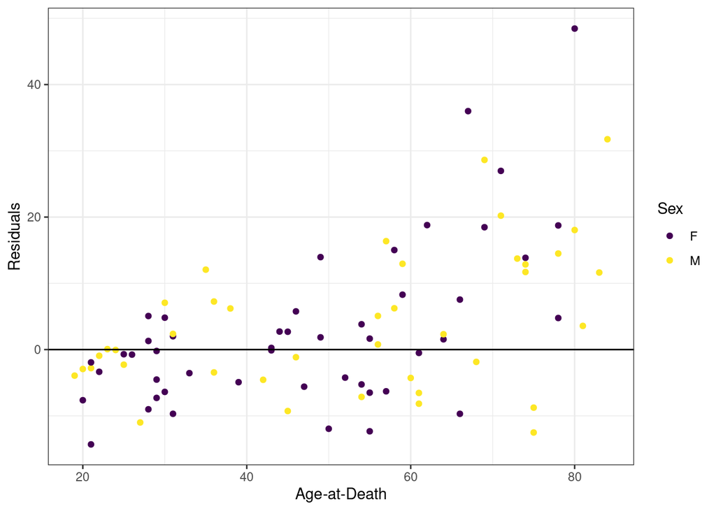

Figure S4.5 Residuals for Snodgrass method, combined regions, plotted against known age-at-death.

```r
data.frame(
  "known_age" = sep_regions$snodgrass$all$known_age,
  "residuals" = snodgrass_wls$all$residuals,
  "sex" = sep_regions$snodgrass$all$sex) %>%
ggplot(aes(x = known_age, y = residuals, col = sex)) +
  geom_point() +
  geom_hline(yintercept = 0) +
  theme_bw() +
  labs(y = "Residuals", x = "Age-at-Death") +
  scale_colour_viridis_d(name = "Sex")
```

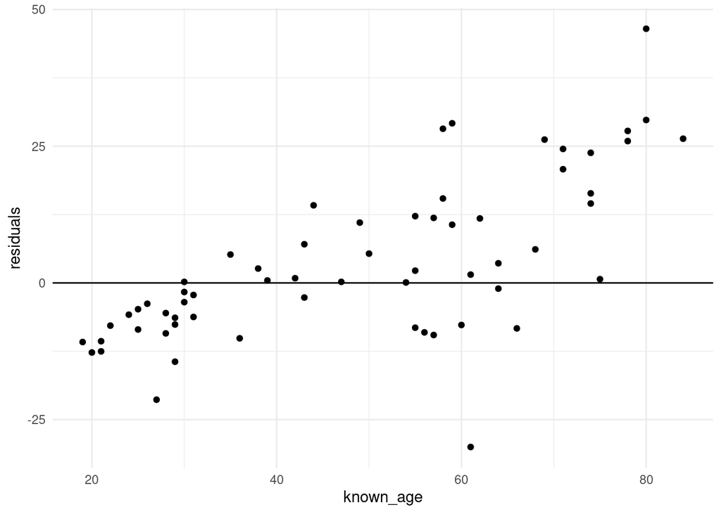

Figure S4.6 Residuals for Snodgrass method, cervical region, plotted against known age-at-death.

```r
data.frame(
  "known_age" = na.omit(sep_regions$snodgrass$cervical)$known_age,
  "residuals" = snodgrass_wls$cervical$residuals) %>%
ggplot(aes(x = known_age, y = residuals)) +
  geom_point() +
  geom_hline(yintercept = 0) +
  theme_minimal()
```

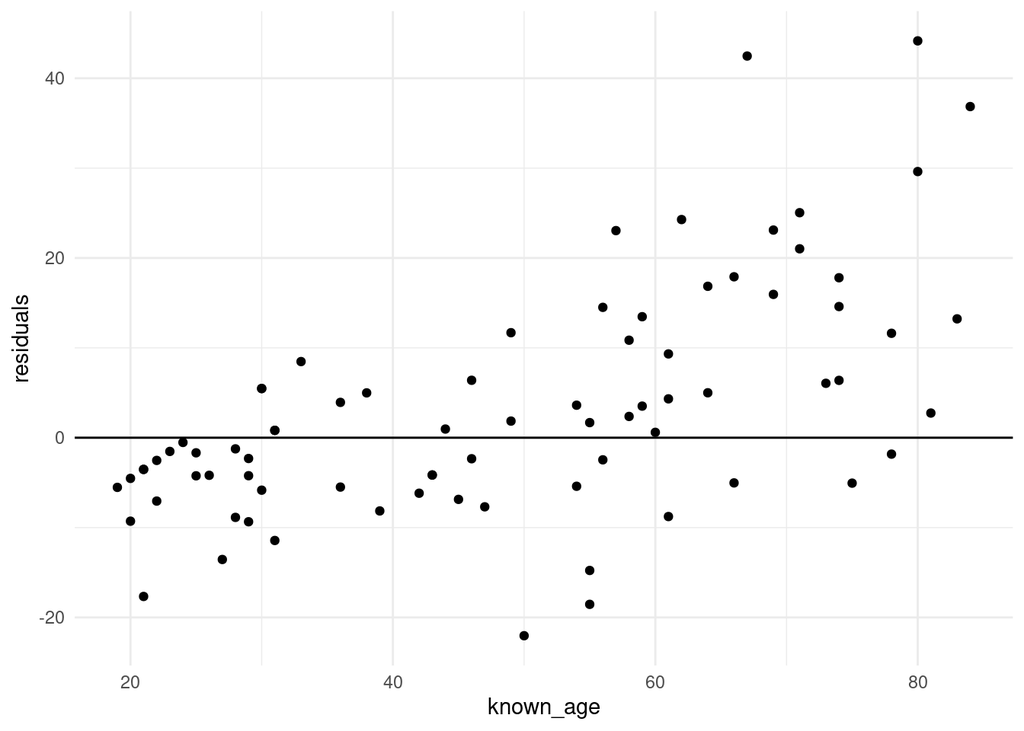

Figure S4.7 Residuals for Snodgrass method, thoracic region, plotted against known age-at-death.

```r
data.frame(
  "known_age" = na.omit(sep_regions$snodgrass$thoracic)$known_age,
  "residuals" = snodgrass_wls$thoracic$residuals) %>%
ggplot(aes(x = known_age, y = residuals)) +
  geom_point() +
  geom_hline(yintercept = 0) +
  theme_minimal()
```

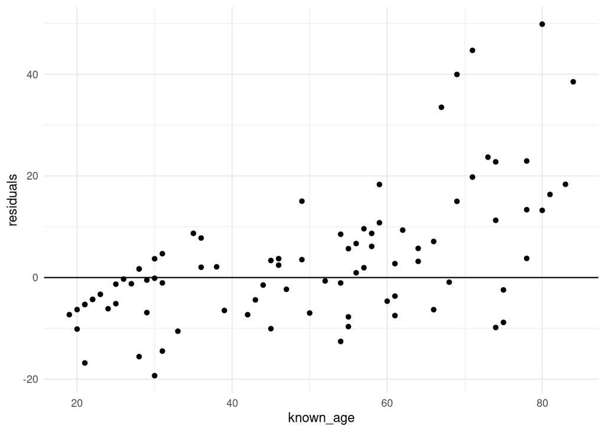

Figure S4.8 Residuals for Snodgrass method, lumbar region, plotted against known age-at-death.

```r
data.frame(
  "known_age" = na.omit(sep_regions$snodgrass$lumbar)$known_age,
  "residuals" = snodgrass_wls$lumbar$residuals) %>%
ggplot(aes(x = known_age, y = residuals)) +
  geom_point() +
  geom_hline(yintercept = 0) +
  theme_minimal()
```

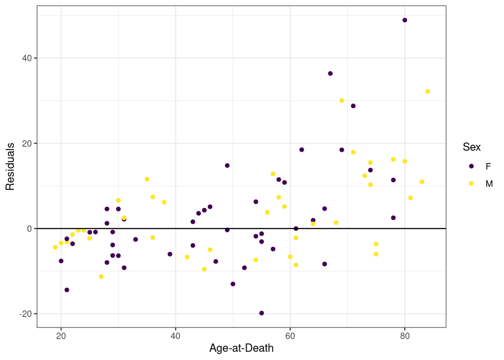

```r
data.frame(
  "known_age" = sep_regions$watanabe$all$known_age,
  "residuals" = watanabe_wls$all$residuals,
  "sex" = sep_regions$watanabe$all$sex) %>%
ggplot(aes(x = known_age, y = residuals, col = sex)) +
  geom_point() +
  geom_hline(yintercept = 0) +
  theme_bw() +
  labs(y = "Residuals", x = "Age-at-Death") +
  scale_colour_viridis_d(name = "Sex")
```

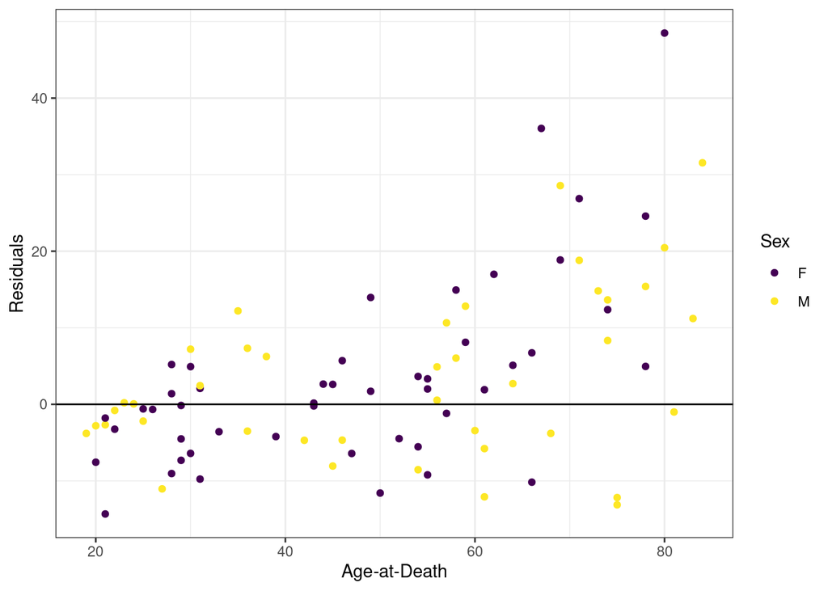

Figure S4.9 Residuals for Praneatpolgrang method, combined regions, plotted against known age-at-death.

```r
data.frame(
  "known_age" = sep_regions$praneatpolgrang$all$known_age,
  "residuals" = praneatpolgrang_wls$all$residuals,
  "sex" = sep_regions$praneatpolgrang$all$sex) %>%
ggplot(aes(x = known_age, y = residuals, col = sex)) +
  geom_point() +
  geom_hline(yintercept = 0) +
  theme_bw() +
  labs(y = "Residuals", x = "Age-at-Death") +
  scale_colour_viridis_d(name = "Sex")
```

What is the accuracy and average residuals (not squared or absolute) per age category?

```r
snodgrass_all_bias <- snodgrass_all_res %>%
  group_by(age_group) %>%
  summarise(n = n(),
            bias_snodgrass = mean(residual))

watanabe_all_bias <- watanabe_all_res %>%
  group_by(age_group) %>%
  summarise(n = n(),
            bias_watanabe = mean(residual))

praneatpolgrang_all_bias <- praneatpolgrang_all_res %>%
  group_by(age_group) %>%
  summarise(n = n(),
            bias_praneat = mean(residual))

all_bias <- list(snodgrass_all_bias, watanabe_all_bias, praneatpolgrang_all_bias)

all_mean_bias <- all_bias %>%
  reduce(inner_join, by = c("age_group", "n"))

knitr::kable(all_mean_bias, caption = "Prediction bias by age for combined regions")
```

Table S4.1 Prediction bias by age for combined regions

| age_group | n | bias_snodgrass | bias_watanabe | bias_praneat |
| --- | --- | --- | --- | --- |
| 1 | 1 | -3.9329403 | -4.4137666 | -3.7969539 |
| 2 | 19 | -3.3326893 | -3.4383567 | -3.2546827 |
| 3 | 12 | 1.1486175 | 1.2234272 | 1.2460393 |
| 4 | 11 | 0.5936718 | -0.3583449 | 0.2461556 |
| 5 | 16 | 1.0287878 | 0.0678360 | 1.6502734 |
| 6 | 13 | 6.3261776 | 6.6678678 | 6.2793092 |
| 7 | 11 | 10.5518121 | 10.8119426 | 10.4041769 |
| 8 | 5 | 22.6911167 | 23.0021529 | 22.1403238 |

```r
snodgrass_cerv_bias <- snodgrass_cerv_res %>%
  group_by(age_group) %>%
  summarise(n = n(),
            snodgrass_bias = mean(residual))

watanabe_cerv_bias <- watanabe_cerv_res %>%
  group_by(age_group) %>%
  summarise(n = n(),
            watanabe_bias = mean(residual))

praneatpolgrang_cerv_bias <- praneatpolgrang_cerv_res %>%
  group_by(age_group) %>%
  summarise(n = n(),
            praneat_bias = mean(residual))

cerv_bias <- list(snodgrass_cerv_bias, watanabe_cerv_bias, praneatpolgrang_cerv_bias)

cerv_mean_bias <- cerv_bias %>%
  reduce(inner_join, by = c("age_group", "n"))

knitr::kable(cerv_mean_bias, caption = "Prediction bias by age for cervical region")
```

Table S4.2 Prediction bias by age for cervical region

| age_group | n | snodgrass_bias | watanabe_bias | praneat_bias |
| --- | --- | --- | --- | --- |
| 1 | 1 | -10.8086074 | -10.4307692 | -12.0532597 |
| 2 | 14 | -9.3672309 | -8.6663419 | -10.4068141 |
| 3 | 9 | -1.6982159 | -0.9720792 | -2.7217721 |
| 4 | 6 | 5.1117731 | 5.2581261 | 4.2796978 |
| 5 | 12 | 7.3745547 | 6.2795447 | 8.3063558 |
| 6 | 9 | 0.2435072 | 1.1252385 | 0.3830655 |
| 7 | 8 | 19.2991972 | 19.8042854 | 20.0121335 |
| 8 | 3 | 34.2163107 | 34.5945123 | 34.2963433 |

```r
snodgrass_thor_bias <- snodgrass_thor_res %>%
  group_by(age_group) %>%
  summarise(n = n(),
            snodgrass_bias = mean(residual))

watanabe_thor_bias <- watanabe_thor_res %>%
  group_by(age_group) %>%
  summarise(n = n(),
            watanabe_bias = mean(residual))

praneatpolgrang_thor_bias <- praneatpolgrang_thor_res %>%
  group_by(age_group) %>%
  summarise(n = n(),
            praneat_bias = mean(residual))

thor_bias <- list(snodgrass_thor_bias, watanabe_thor_bias, praneatpolgrang_thor_bias)

thor_mean_bias <- thor_bias %>%
  reduce(inner_join, by = c("age_group", "n"))

knitr::kable(thor_mean_bias, caption = "Prediction bias by age for thoracic region")
```

Table S4.3 Prediction bias by age for thoracic region

| age_group | n | snodgrass_bias | watanabe_bias | praneat_bias |
| --- | --- | --- | --- | --- |
| 1 | 1 | -5.5256740 | -6.3887656 | -4.8695061 |
| 2 | 18 | -5.5445962 | -5.8268562 | -5.0920400 |
| 3 | 11 | -0.0845294 | -0.0842103 | 0.3581641 |
| 4 | 10 | -1.0468731 | -2.8772647 | -1.5781927 |
| 5 | 13 | 0.7576514 | 1.3798364 | 1.5967547 |
| 6 | 12 | 12.1684760 | 12.4541515 | 11.8964329 |
| 7 | 9 | 10.6273014 | 11.5278913 | 9.7542369 |
| 8 | 5 | 25.3214421 | 25.5489227 | 22.8387228 |

```r
snodgrass_lumb_bias <- snodgrass_lumb_res %>%
  group_by(age_group) %>%
  summarise(n = n(),
            snodgrass_bias = mean(residual))

watanabe_lumb_bias <- watanabe_lumb_res %>%
  group_by(age_group) %>%
  summarise(n = n(),
            watanabe_bias = mean(residual))

praneatpolgrang_lumb_bias <- praneatpolgrang_lumb_res %>%
  group_by(age_group) %>%
  summarise(n = n(),
            praneat_bias = mean(residual))

lumb_bias <- list(snodgrass_lumb_bias, watanabe_lumb_bias, praneatpolgrang_lumb_bias)

lumb_mean_bias <- lumb_bias %>%
  reduce(inner_join, by = c("age_group", "n"))

knitr::kable(lumb_mean_bias, caption = "Prediction bias by age for lumbar region")
```

Table S4.4 Prediction bias by age for lumbar region

| age_group | n | snodgrass_bias | watanabe_bias | praneat_bias |
| --- | --- | --- | --- | --- |
| 1 | 1 | -7.2991963 | -7.7693094 | -8.0168617 |
| 2 | 18 | -4.9639622 | -5.2623760 | -5.5375607 |
| 3 | 12 | -1.9137817 | -2.2956140 | -2.2092975 |
| 4 | 10 | 0.2545196 | -0.0382005 | 0.4354296 |
| 5 | 16 | 2.4181210 | 1.3541013 | 2.7671487 |
| 6 | 13 | 7.1993127 | 7.2729990 | 8.8715273 |
| 7 | 11 | 12.8360094 | 13.5599795 | 11.8832422 |
| 8 | 5 | 27.2639918 | 27.6389654 | 28.6810396 |